# STAT 626 Project - Version 3

Ken Marciel

7/30/2021

### Packages

```r
library(readxl) # for read_excel function
library(astsa) # for time series functions
```

### Data

```r
# Read data from Excel file (compiled by Jack Kramer)
setwd("C:/Users/keoka/OneDrive - Texas A&M University/Courses/STAT_626/Project/Data Analysis/Jack/")
data = read.csv("consolidated_data.csv")
class(data) # data frame
dim(data) # 460 rows, 41 columns
head(data) # preview the first six rows of data set
names(data) # display the column names of data set

# Keep only the columns desired for analysis
match("year", colnames(data)) # column 41
match("month", colnames(data)) # column 40
match("total.red.meat", colnames(data)) # column 7
match("total.poultry", colnames(data)) # column 16
match("Population_Millions", colnames(data)) # column 21
match("Personal.Income", colnames(data)) # column 19
data = data[,c(41,40,7,16,21,19)]

# Change column names to have a consistent format
colnames(data) = c("Year", "Month","Red_Meat", "Poultry", "Population",
                   "Personal_Income")

# Review structure of the data set
class(data) # data frame
dim(data) # 460 rows, 6 columns
head(data) # preview the first six rows of reduced data set
str(data)

# Create variables to store data columns
year = data[,1]
mont = data[,2]
meat = data[,3] # total U.S. red meat production in millions of pounds
poul = data[,4] # total U.S. poultry production in millions of pounds
popu = data[,5] # U.S. population in millions
inco = data[,6] # U.S. personal income in billions of dollars

# Range of observations for the Great Depression
data[which(data$Year==2007 & data$Month==12),] # row 300
data[which(data$Year==2009 & data$Month==6),] # row 318

# Start of observations for the COVID-19 Pandemic
data[which(data$Year==2020 & data$Month==3),] # row 447
```

### Exploratory Data Analysis: Time Series Plotted Separately

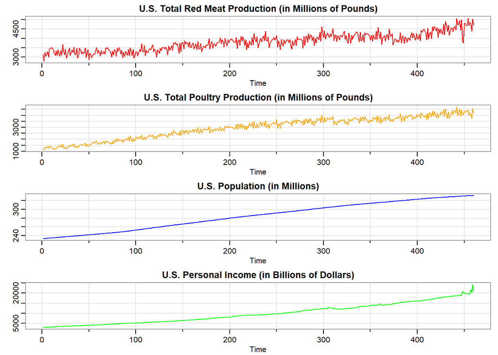

```r
par(mfrow=c(4,1))
tsplot(meat, main="U.S. Total Red Meat Production (in Millions of Pounds)",
       col="red", ylab="")
tsplot(poul, main="U.S. Total Poultry Production (in Millions of Pounds)",
       col="orange", ylab="")
tsplot(popu, main="U.S. Population (in Millions)",
       col="blue", ylab="")
tsplot(inco, main="U.S. Personal Income (in Billions of Dollars)",
       col="green", ylab="")
```

Note the upward trend in all of the series, and the apparent seasonality in the meat and poultry series.

### Exploratory Data Analysis: Time Series Plotted Together

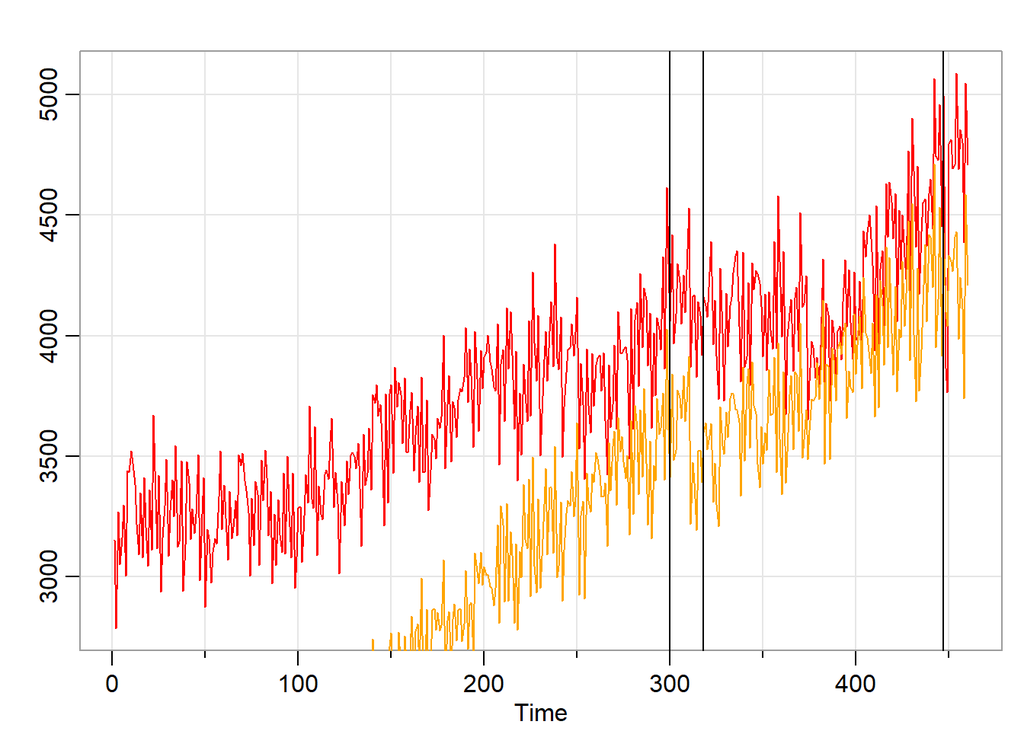

```r
tsplot(meat, main="", ylab="", col="red")
lines(poul, col="orange")
abline(v=c(300,318,447))
```

Note that poultry has a steeper upward trend than red meat. Both series display a downard trend during the Great Recession (December 2007 to June 2009), and a leveling off during the COVID-19 pandemic (March 2020 to present). Both series have similar seasonality.

#### Exploratory Data Analysis: Scatterplot Matrix

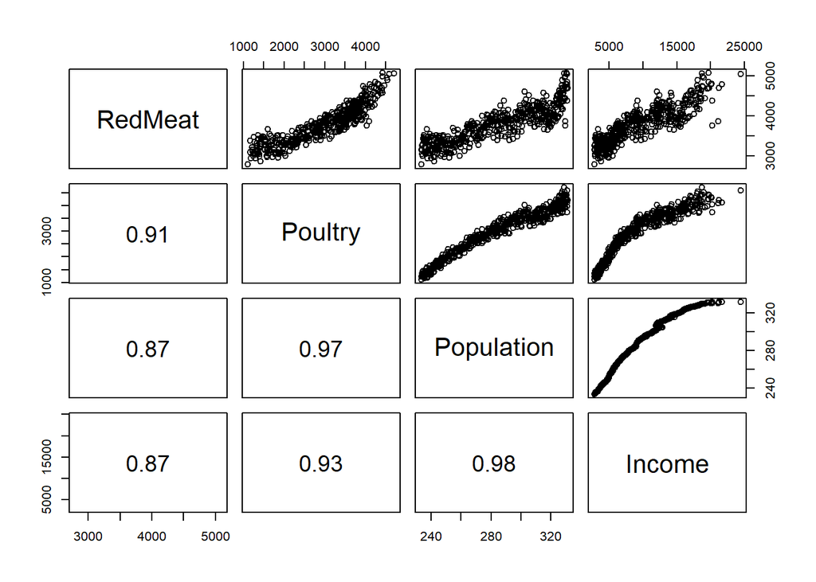

```r
# Code from page 43 of textbook: Shumway, Stoffer (2019)
panel.cor = function(x, y, ...){
  usr = par("usr"); on.exit(par(usr))
  par(usr = c(0,1,0,1))
  r = round(cor(x, y), 2)
  text(0.5, 0.5, r, cex=1.75)
}
pairs(cbind(RedMeat=meat, Poultry=poul, Population=popu, Income=inco), lower.panel=panel.cor)
```

The scatterplot matrix indicates that red meat is nonlinearly related to population and income, and the same is true for poultry. Population and income are highly correlated, and have nearly identical correlation coefficients for red meat and poultry.

For ease, let $M_{t}$ denote total red meat production, $P_{t}$ denote total poultry production, $L_{t}$ denote total population, and $I_{t}$ denote total personal income. Also, let $L.$ and $I.$ denote the mean of population, and the mean of personal income, respectively.

#### Exploratory Data Analysis: Collinearity

```r
par(mfrow=2:1)
plot(popu, popu^2) # collinear
cor(popu, popu^2)
```

```
## [1] 0.9990233
```

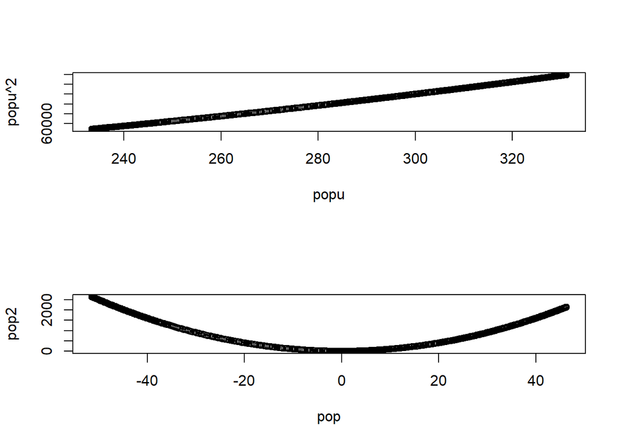

```r
pop = popu - mean(popu) # center population
pop2 = pop^2
plot(pop, pop2) # not collinear
```

```r
cor(pop, pop2)
```

```
## [1] -0.1503336
```

```r
par(mfrow=2:1)
plot(inco, inco^2) # collinear
cor(inco, inco^2)
```

```
## [1] 0.9763314
```

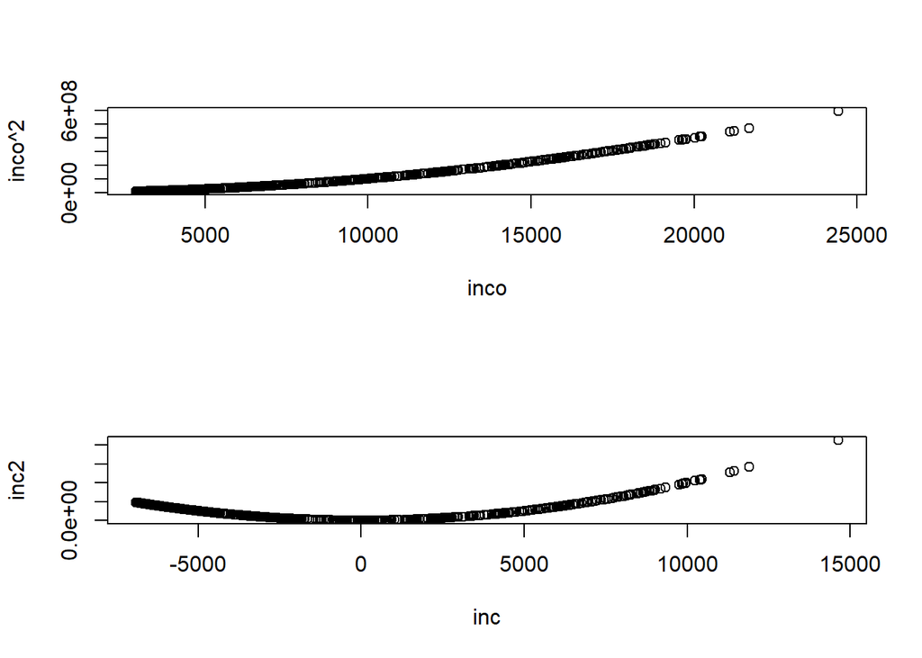

```r
inc = inco - mean(inco) # center income
inc2 = inc^2
plot(inc, inc2)
```

```r
cor(inc, inc2)
```

```
## [1] 0.4068634
```

For this data set, $L_{t}$ and $L_{t}^2$ are highly collinear, but $L_{t}-L.$ and $(L_{t}-L.)^2$ are not. Similarly, $I_{t}$ and $I_{t}^2$ are highly collinear, while $I_{t}-I.$ and $(I_{t}-I.)^2$ are moderately collinear. Therefore, it is better to include $L_{t}$ instead of $I_{t}$ in the model.